# Scotland Cancer Analysis 2015 to 2019

# Introduction

The report is to analysis the dataset of the NHS Scotland to help them to get know more about the type of cancer and who is efect the most by age or gender this can help planning for provision of cancer treatment services in NHS Borders.

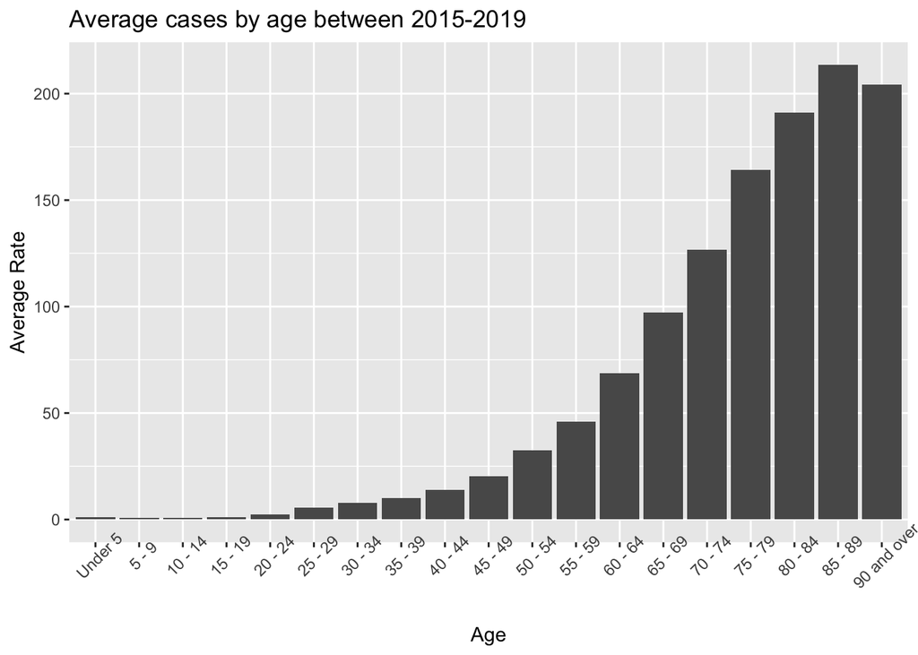

The total number of cases is been increased by the age, the cases increased as the age increases until reach the peak at age 85-89.

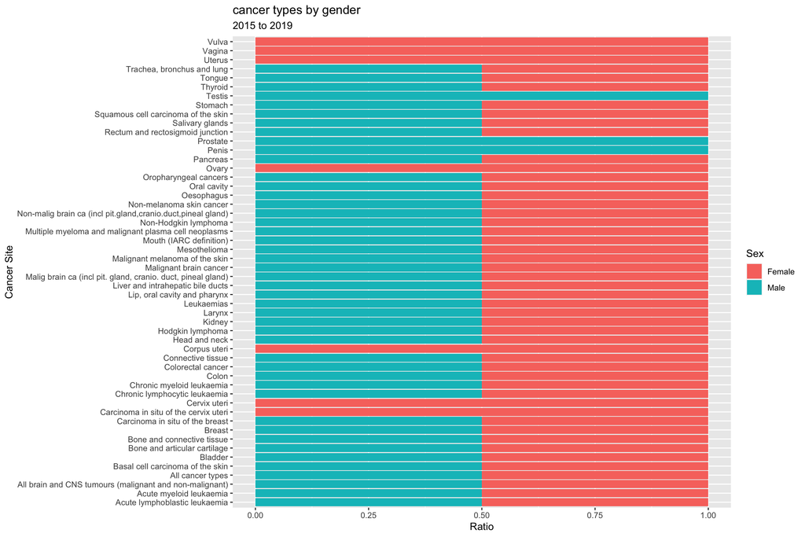

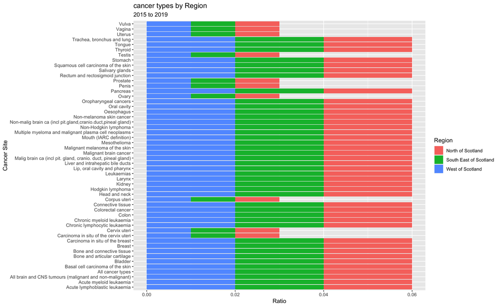

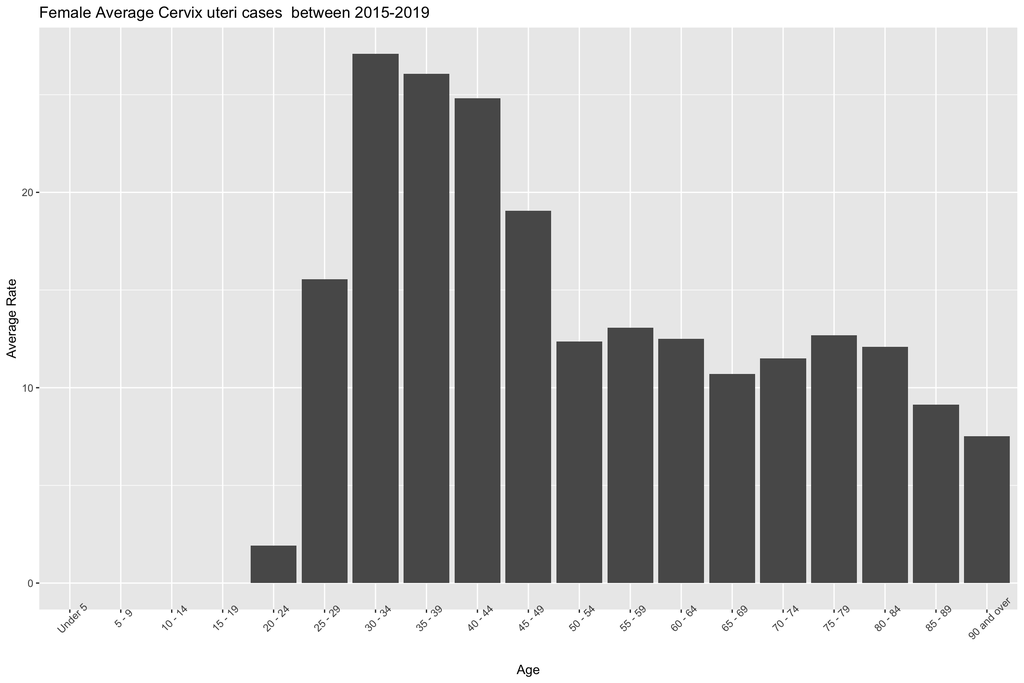

The plot above shows one type of cncer that effect the women most, the graph shows the number of cases between 2015 -2019 by ages. You can see that most ages are efected the age between 25-49, age 49 and obove are also shows thats women in that age still effect them but not the same as 25-49.